# Analysis to create parameters for PTR/B

Pete Dodd

October, 2019

#Pre-amble (Last updated: 2019-11-01 15:11:48)

This describes analyses of various sources of data to inform decision model parameters

N.B. This file should render to html with `rmarkdown::render('Parameters3.R')` or from the command line with `R -q -e "rmarkdown::render(\"Parameters3.R\")"`

## Load libraries

Relevant libraries for loading and manipulating data:

```r
rm(list=ls())
library(here)
library(data.table)
library(readxl)
library(HEdtree)
```

```r
library(data.tree)
library(ggplot2)
library(ggrepel)
library(stringr)
library(viridis)
knitr::opts_chunk$set(cache=FALSE)

## === utilities
logit <- function(x) log(x/(1-x))
ilogit <- function(x) 1/(exp(-x)+1)
relogit <- function(x,RR) ilogit(RR*logit(x))
odds <- function(x) (x/(1-x))
iodds <- function(x) x/(x+1)
reodds <- function(x,RR) iodds(RR*odds(x))
```

## Load data

Look at Excel data:

```r
XL <- read_excel("Parameters_v1.xlsx", sheet = "Parameters")
XL <- as.data.table(XL)
XX <- XL[!is.na(`Point estimate`),
         .(Parameter,
           Treatment,
           `Age group`,
           `Point estimate`,
           `95% lower`,
           `95% upper`,`Source`)]
XX
```

```
##                                                                              Parameter
##  1:                                                                   Efficacy in TST+
##  2:                                                                   Efficacy in TST+
##  3:                                                                   Efficacy in TST+
##  4:                                                                   Efficacy in TST+
##  5: AE (grade 3-5 attributed to study drug that resulted in treatment discontinuation)
##  6: AE (grade 3-5 attributed to study drug that resulted in treatment discontinuation)
##  7: AE (grade 3-5 attributed to study drug that resulted in treatment discontinuation)
##  8: AE (grade 3-5 attributed to study drug that resulted in treatment discontinuation)
##  9: AE (grade 3-5 attributed to study drug that resulted in treatment discontinuation)
## 10: AE (grade 3-5 attributed to study drug that resulted in treatment discontinuation)
## 11: AE (grade 3-5 attributed to study drug that resulted in treatment discontinuation)
## 12: AE (grade 3-5 attributed to study drug that resulted in treatment discontinuation)
## 13: AE (grade 3-5 attributed to study drug that resulted in treatment discontinuation)
## 14: AE (grade 3-5 attributed to study drug that resulted in treatment discontinuation)
```

[output cut: 57 more lines]

Age categories

```r
acat <- c("0-17","18-34","35-64","65+")
```

# Preventive therapy

## Regimen = 6H

Change 9H to 6H

```r
XX[Treatment=='9H',Treatment:='6H']
```

First looing at AEs

```r
(XA <- XX[grepl('AE',Parameter) &
          grepl('6H',Treatment) &
         !is.na(`95% upper`),
         .(`Treatment`, `Age group`, `Point estimate`,
           `95% lower`, `95% upper`,`Source`)])
```

```
##    Treatment Age group Point estimate 95% lower 95% upper
## 1:        6H     00-17     0.00000000    0.0000    0.0093
## 2:        6H     18-34     0.01541696    0.0102    0.0232
## 3:        6H     35-64     0.02801462    0.0211    0.0372
## 4:        6H       65+     0.05511811    0.0270    0.1094
##                          Source
## 1: Menzies 2018 pediatric trial
## 2:     Menzies unpublished data
## 3:     Menzies unpublished data
## 4:     Menzies unpublished data
```

```r
## add relevant
XA[,NAME:=paste0("AE.6H.",acat)]
XA[,SOURCE:=Source]
XA[,NOTE:=""]
XA[,DESCRIPTION:=c("6H AE probability, ages 0-17",
                   "6H AE probability, ages 18-34",
                   "6H AE probability, ages 35-64",
                   "6H AE probability, ages 65+")]

## get parms
tmp <- getAB(XA[,`Point estimate`],(XA[,`95% upper`]-XA[,`95% lower`])^2/3.92^2)
XA[,DISTRIBUTION:=paste0("B(",tmp$a,",",tmp$b,")")] #beta distributions
## top 1 has to exponential
(aa <- XA[1,`95% upper`])
```

```
## [1] 0.0093
```

```r
(bb <- -log(1-.975)/aa)
```

```
## [1] 396.6537
```

```r
XA[1,DISTRIBUTION:=paste0("E(",bb,")")] #beta distributions
```

Start data table of parameters

```r
(PDT <- XA[,.(NAME,DISTRIBUTION,DESCRIPTION,SOURCE,NOTE)])
```

```
##           NAME                         DISTRIBUTION
## 1:  AE.6H.0-17                  E(396.653704743434)
## 2: AE.6H.18-34  B(21.2627981971801,1357.9196121381)
## 3: AE.6H.35-64 B(45.1939550148373,1568.03374355827)
## 4:   AE.6H.65+ B(6.44144817333538,110.424825828607)
##                      DESCRIPTION                       SOURCE NOTE
## 1:  6H AE probability, ages 0-17 Menzies 2018 pediatric trial
## 2: 6H AE probability, ages 18-34     Menzies unpublished data
## 3: 6H AE probability, ages 35-64     Menzies unpublished data
## 4:   6H AE probability, ages 65+     Menzies unpublished data
```

Efficacy:

NOTE no data in Excel spreadsheet on 6H; assuming same as 6H

```r
(XA <- XX[grepl('Efficacy',Parameter) &
          grepl('6H',Treatment) &
         !is.na(`95% upper`),
         .(`Treatment`, `Age group`, `Point estimate`,
           `95% lower`, `95% upper`,`Source`)])
```

```
##    Treatment Age group Point estimate 95% lower 95% upper
## 1:        6H       All            0.4      0.26       0.6
##                               Source
## 1: Zenner 2018 network meta-analysis
```

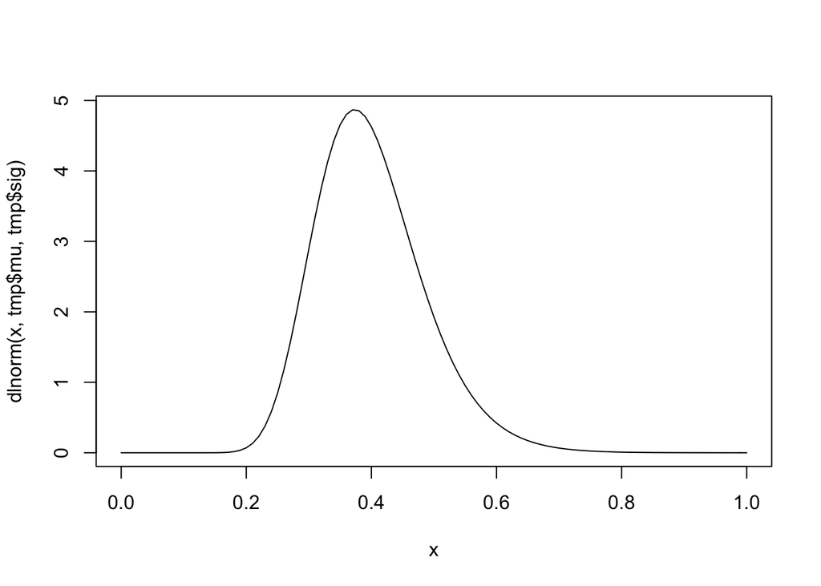

```r
## add relevant
XA[,NAME:="OR.6H"]
XA[,SOURCE:=Source]
XA[,NOTE:=""]
XA[,DESCRIPTION:="6H efficacy TST+ as OR, all ages"]
tmp <- getLNparms(XA[,`Point estimate`],(XA[,`95% upper`]-XA[,`95% lower`])^2/3.92^2,med=FALSE)
curve(dlnorm(x,tmp$mu,tmp$sig))
```

```r
XA[,DISTRIBUTION:=paste0("LN(",tmp$mu,",",tmp$sig,")")] #LN distributions
PDT <- rbind(PDT,XA[,.(NAME,DISTRIBUTION,DESCRIPTION,SOURCE,NOTE)])
```

## Regimen = 4R

```r
(XA <- XX[grepl('AE',Parameter) &
          grepl('4R',Treatment) &
         !is.na(`95% upper`),
         .(`Treatment`, `Age group`, `Point estimate`,
           `95% lower`, `95% upper`,`Source`)])
```

```
##    Treatment Age group Point estimate 95% lower 95% upper
## 1:        4R     00-17    0.000000000    0.0000    0.0090
## 2:        4R     18-34    0.008730692    0.0051    0.0149
## 3:        4R     35-64    0.009030704    0.0055    0.0149
## 4:        4R       65+    0.023076923    0.0079    0.0657
##                          Source
## 1: Menzies 2018 pediatric trial
## 2:     Menzies unpublished data
## 3:     Menzies unpublished data
## 4:     Menzies unpublished data
```

```r
## add relevant
XA[,NAME:=paste0("AE.4R.",acat)]
XA[,SOURCE:=Source]
XA[,NOTE:=""]
XA[,DESCRIPTION:=c("4R AE probability, ages 0-17",
                   "4R AE probability, ages 18-34",
                   "4R AE probability, ages 35-64",
                   "4R AE probability, ages 65+")]
## get parms
tmp <- getAB(XA[,`Point estimate`],(XA[,`95% upper`]-XA[,`95% lower`])^2/3.92^2)
XA[,DISTRIBUTION:=paste0("B(",tmp$a,",",tmp$b,")")] #beta distributions
## top 1 has to exponential
(aa <- XA[1,`95% upper`])
```

```
## [1] 0.009
```

```r
(bb <- -log(1-.95)/aa)
```

```
## [1] 332.8591
```

```r
XA[1,DISTRIBUTION:=paste0("E(",bb,")")] #beta distributions
```

Add to data table of parameters

```r
PDT <- rbind(PDT,XA[,.(NAME,DISTRIBUTION,DESCRIPTION,SOURCE,NOTE)])
```

Efficacy:

```r
(XA <- XX[grepl('Efficacy',Parameter) & grepl('4R',Treatment),
         .(`Treatment`, `Age group`, `Point estimate`,
           `95% lower`, `95% upper`,`Source`)])
```

```
##    Treatment Age group Point estimate 95% lower 95% upper
## 1:        4R       All           0.36      0.18      0.73
##                               Source
## 1: Zenner 2018 network meta-analysis
```

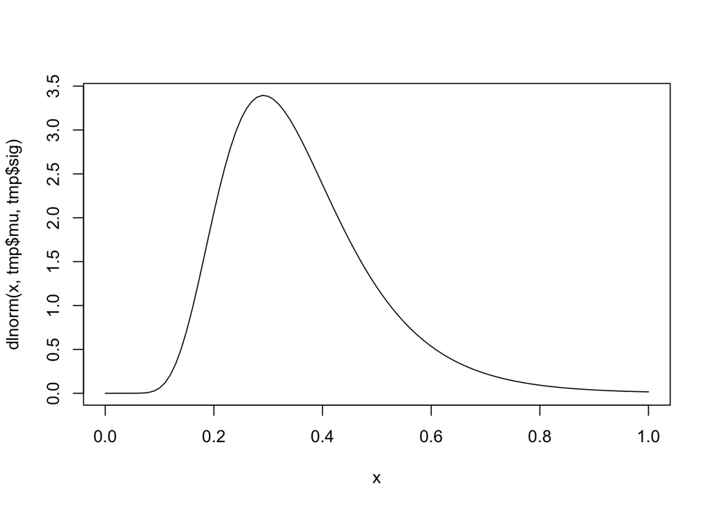

```r
## add relevant
XA[,NAME:="OR.4R"]
XA[,SOURCE:=Source]
XA[,NOTE:=""]
XA[,DESCRIPTION:="4R efficacy TST+ as OR, all ages"]
tmp <- getLNparms(XA[,`Point estimate`],(XA[,`95% upper`]-XA[,`95% lower`])^2/3.92^2,med=FALSE)
curve(dlnorm(x,tmp$mu,tmp$sig))
```

```r
XA[,DISTRIBUTION:=paste0("LN(",tmp$mu,",",tmp$sig,")")] #LN distributions
```

Add to data table of parameters

```r
PDT <- rbind(PDT,XA[,.(NAME,DISTRIBUTION,DESCRIPTION,SOURCE,NOTE)])
```

## Regimen = 3HP

```r
(XA <- XX[grepl('AE',Parameter) &
          grepl('3HP',Treatment) &
         !is.na(`95% upper`),
         .(`Treatment`, `Age group`, `Point estimate`,
           `95% lower`, `95% upper`,`Source`)])
```

```
##    Treatment Age group Point estimate  95% lower  95% upper
## 1:       3HP     00-17    0.005565863 0.00190000 0.01620000
## 2:       3HP     18-34    0.020278834 0.01391105 0.02850791
## 3:       3HP     35-64    0.041858091 0.03342693 0.05169276
## 4:       3HP       65+    0.083870968 0.04541441 0.13915149
##                            Source
## 1: Villarino 2015 pediatric trial
## 2:                 Sterling trial
## 3:                 Sterling trial
## 4:                 Sterling trial
```

```r
## add relevant
XA[,NAME:=paste0("AE.3HP.",acat)]
XA[,SOURCE:=Source]
XA[,NOTE:=""]
XA[,DESCRIPTION:=c("4R AE probability, ages 0-17",
                   "4R AE probability, ages 18-34",
                   "4R AE probability, ages 35-64",
                   "4R AE probability, ages 65+")]
## get parms
tmp <- getAB(XA[,`Point estimate`],(XA[,`95% upper`]-XA[,`95% lower`])^2/3.92^2)
XA[,DISTRIBUTION:=paste0("B(",tmp$a,",",tmp$b,")")] #beta distributions
```

Add to data table of parameters

```r
PDT <- rbind(PDT,XA[,.(NAME,DISTRIBUTION,DESCRIPTION,SOURCE,NOTE)])
```

Efficacy:

```r
(XA <- XX[grepl('Efficacy',Parameter) & grepl('3HP',Treatment),
         .(`Treatment`, `Age group`, `Point estimate`,
           `95% lower`, `95% upper`,`Source`)])
```

```
##    Treatment Age group Point estimate 95% lower 95% upper
## 1:       3HP       All           0.25      0.11      0.57
##                               Source
## 1: Zenner 2018 network meta-analysis
```

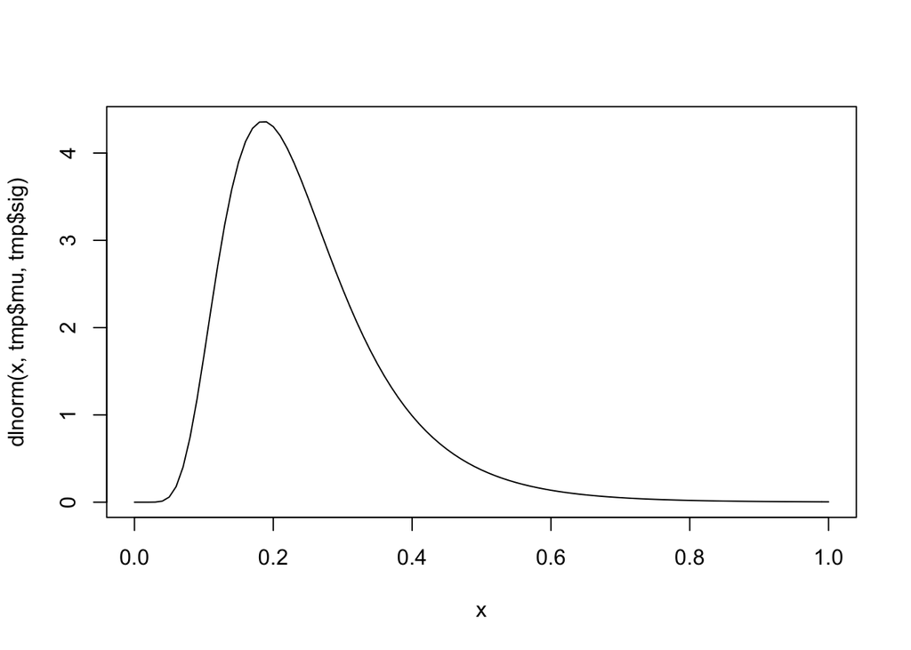

```r
## add relevant
XA[,NAME:="OR.3HP"]
XA[,SOURCE:=Source]
XA[,NOTE:=""]
XA[,DESCRIPTION:="3HP efficacy TST+ as OR, all ages"]
tmp <- getLNparms(XA[,`Point estimate`],(XA[,`95% upper`]-XA[,`95% lower`])^2/3.92^2,med=FALSE)
curve(dlnorm(x,tmp$mu,tmp$sig))
```

```r
XA[,DISTRIBUTION:=paste0("LN(",tmp$mu,",",tmp$sig,")")] #LN distributions
```

Add to data table of parameters

```r
PDT <- rbind(PDT,XA[,.(NAME,DISTRIBUTION,DESCRIPTION,SOURCE,NOTE)])
```

# Efficacy of Preventive therapy efficacy: TST+ vs -

NOTE current decision to consider this as 1.

# Progression to TB disease

## TST+

Using Trauer’s adjusted estimates, however including 1 and 3 month cut-offs at the start time to exclude co-prevalent cases, and 1 and 3 year end-points. Primary analysis decided as 3y/3mo.

```r
## knitr::include_graphics('Trauer2.jpg')
```

(approximate digitization)

```r
trauer <- data.table(age=rep(c('0-4','5-14','15+'),4),
                     p.hi=c(c(0.21,0.12,.006),
                       c(0.53,0.22,.016),
                       c(.71,.35,.04),
                       c(.71,.36,.05)),
                     p=c(c(0.18,.07,.001),
                         c(0.39,0.15,.006),
                         c(.56,.28,0.02),
                         c(.56,0.28,.03)),
                     p.lo=c(c(0.13,.025,0),
                            c(0.26,.09,0),
                            c(.41,.17,.01),
                            c(.41,0.18,.009)),
                     time=c(rep('1 month',3), #30 d
                            rep('3 month',3), #90 d
                            rep('1 year',3),  #365 d
                            rep('3 year',3))) #1095 d

fwrite(trauer[,.(time,age,p,p.lo,p.hi)],file=here('figures/S_TrauerData.csv'))
```

Add beta parameters and inspect

```r
trauer[,c('a','b'):=getAB(p,(p.hi-p.lo)^2/3.92^2)]
knitr::kable(trauer)
```

| age | p.hi | p | p.lo | time | a | b |
| --- | --- | --- | --- | --- | --- | --- |
| 0-4 | 0.210 | 0.180 | 0.130 | 1 month | 63.6097680 | 289.77783 |
| 5-14 | 0.120 | 0.070 | 0.025 | 1 month | 7.6889678 | 102.15343 |
| 15+ | 0.006 | 0.001 | 0.000 | 1 month | 0.4254176 | 424.99218 |
| 0-4 | 0.530 | 0.390 | 0.260 | 3 month | 19.1670639 | 29.97925 |
| 5-14 | 0.220 | 0.150 | 0.090 | 3 month | 17.2394911 | 97.69045 |
| 15+ | 0.016 | 0.006 | 0.000 | 3 month | 2.1419346 | 354.84717 |
| 0-4 | 0.710 | 0.560 | 0.410 | 1 year | 22.9990815 | 18.07071 |
| 5-14 | 0.350 | 0.280 | 0.170 | 1 year | 26.4916836 | 68.12147 |
| 15+ | 0.040 | 0.020 | 0.010 | 1 year | 6.6729209 | 326.97312 |
| 0-4 | 0.710 | 0.560 | 0.410 | 3 year | 22.9990815 | 18.07071 |
| 5-14 | 0.360 | 0.280 | 0.180 | 3 year | 26.4916836 | 68.12147 |
| 15+ | 0.050 | 0.030 | 0.009 | 3 year | 7.9502898 | 257.05937 |

Visualize distributions

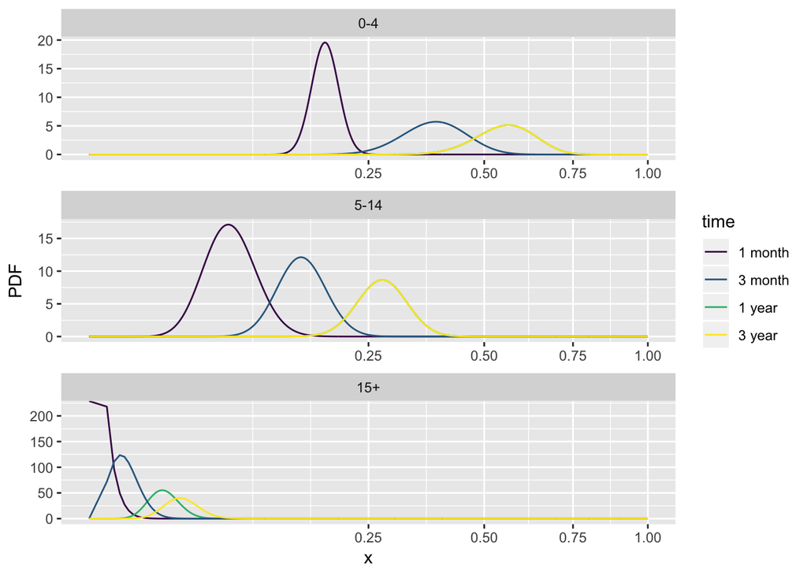

```r
## make data
nn <- 1e3
xx <- seq(from=0,to=1,len=nn)
TD <- as.data.table(expand.grid(x=xx,
                                age=trauer[,unique(age)],
                                time=trauer[,unique(time)]))
TD <- merge(TD,trauer[,.(age,time,a,b)],by=c('age','time'),all.x=TRUE)
TD[,PDF:=dbeta(x,shape1 = a,shape2 = b)]
TD$time <- factor(TD$time,levels=c('1 month','3 month','1 year','3 year'),ordered=TRUE)
TD$age <- factor(TD$age,levels=c('0-4','5-14','15+'),ordered=TRUE)

ggplot(TD,aes(x,PDF,col=time,group=paste(age,time))) +
  geom_line() +
  facet_wrap(~age,ncol=1,scales='free')  + scale_x_sqrt()
```

NOTE only 3 time curves are visible in some age groups due to completion of events meaning that 1 year risks are identical to 3 year risks

How to approach the difference of these variables?

Check reasonable to use mean/variance of differences:

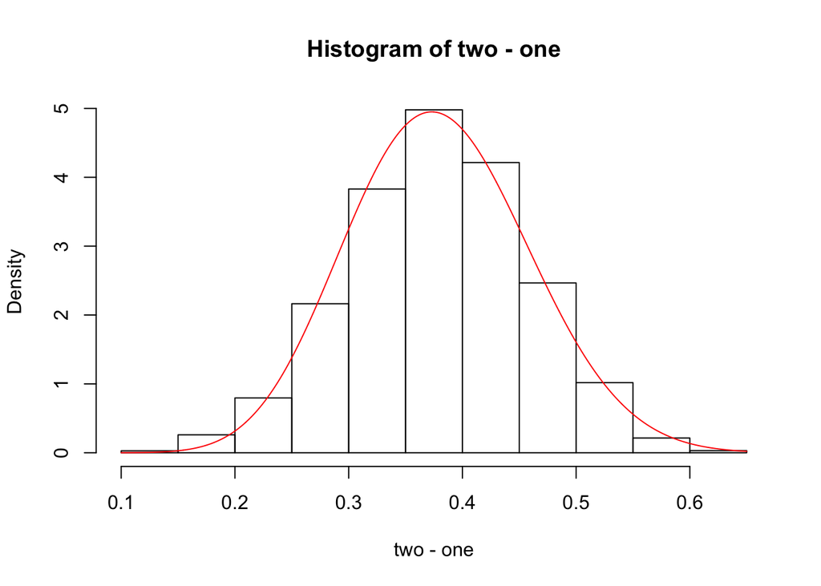

```r
## data
one <- rbeta(1e4,trauer[age=='0-4' & time=='1 month',a],
             trauer[age=='0-4' & time=='1 month',b])
two <- rbeta(1e4,trauer[age=='0-4' & time=='1 year',a],
             trauer[age=='0-4' & time=='1 year',b])

## mean & var
mn <- trauer[age=='0-4' & time=='1 year',a/(a+b)] - trauer[age=='0-4' & time=='1 month',a/(a+b)]
vn <- trauer[age=='0-4' & time=='1 year',a*b/(a+b)^2/(a+b+1)] + trauer[age=='0-4' & time=='1 month',a*b/(a+b)^2/(a+b+1)]
AB <- getAB(mn,vn)

## plot
hist(two-one,freq=FALSE)
curve(dbeta(x,shape1=AB$a,shape2=AB$b),n=1e3,col=2,add=TRUE)
```

Make new data for difference combinations

```r
trauer2 <- copy(trauer[,.(age,time,a,b)])
trauer2[,c('mn','vn'):=.(a/(a+b),a*b/(a+b)^2/(a+b+1))]
T2 <- dcast(trauer2[,.(age,time,mn,vn)],age ~ time,value.var = c('mn','vn'))

## make bits of new data
tz <- c('1 to 12 months','1 to 36 months','3 to 12 months','3 to 36 months')
AB11 <- T2[,getAB(`mn_1 year`-`mn_1 month`,`vn_1 year`+`vn_1 month`)]
AB13 <- T2[,getAB(`mn_1 year`-`mn_3 month`,`vn_1 year`+`vn_3 month`)]
AB31 <- T2[,getAB(`mn_3 year`-`mn_1 month`,`vn_3 year`+`vn_1 month`)]
AB33 <- T2[,getAB(`mn_3 year`-`mn_3 month`,`vn_3 year`+`vn_3 month`)]
AB11[,time:='1 to 12 months']; AB13[,time:='3 to 12 months'];
AB31[,time:='1 to 36 months']; AB33[,time:='3 to 36 months']
ABBA <- rbindlist(list(AB11,AB31,AB13,AB33))
ABBA[,age:=rep(T2$age,4)]
ABBA[,c('mn','vn'):=.(a/(a+b),a*b/(a+b)^2/(a+b+1))]
ABBA
```

```
##             a         b           time  age    mn           vn
##  1: 13.890986  22.66424 1 to 12 months  0-4 0.380 6.273428e-03
##  2:  5.794966 299.20325 1 to 12 months  15+ 0.019 6.091212e-05
##  3: 12.713356  47.82643 1 to 12 months 5-14 0.210 2.695817e-03
##  4: 13.890986  22.66424 1 to 36 months  0-4 0.380 6.273428e-03
##  5:  7.279312 243.73144 1 to 36 months  15+ 0.029 1.117373e-04
##  6: 12.713356  47.82643 1 to 36 months 5-14 0.210 2.695817e-03
##  7:  2.092700  10.21730 3 to 12 months  0-4 0.170 1.060105e-02
##  8:  2.554901 179.93799 3 to 12 months  15+ 0.014 7.522907e-05
##  9:  4.452803  29.79953 3 to 12 months 5-14 0.130 3.208299e-03
## 10:  2.092700  10.21730 3 to 36 months  0-4 0.170 1.060105e-02
## 11:  4.435794 180.38896 3 to 36 months  15+ 0.024 1.260542e-04
## 12:  4.452803  29.79953 3 to 36 months 5-14 0.130 3.208299e-03
```

Now need weighted average for under 18s

```r
ABBA2 <- data.table(expand.grid(time=ABBA[,unique(time)],age=acat))
ABBA2 <- merge(ABBA2,ABBA[age=='15+',.(time,a,b)],by='time') #adults

## weight over children
AY <- ABBA[age=='0-4']; AO <- ABBA[age=='5-14']
AB <- merge(AY[,.(time,mny=mn,vny=vn)],AO[,.(time,mno=mn,vno=vn)],by='time')
AB[,c('mn','vn'):=.((mny+2*mno)/3,(vny+2*vno)/3)]
AB[,c('a2','b2'):=getAB(mn,vn)]
AB[,.(time,mny,mno,mn,a2,b2)]
```

```
##              time  mny  mno        mn        a2       b2
## 1: 1 to 12 months 0.38 0.21 0.2666667 13.144702 36.14793
## 2: 1 to 36 months 0.38 0.21 0.2666667 13.144702 36.14793
## 3: 3 to 12 months 0.17 0.13 0.1433333  2.959282 17.68687
## 4: 3 to 36 months 0.17 0.13 0.1433333  2.959282 17.68687
```

```r
## merge and clean
ABBA2 <- merge(ABBA2,AB[,.(time,a2,b2)],by='time',all.x = TRUE)
ABBA2[age=='0-17',c('a','b'):=.(a2,b2)]
ABBA2[,c('a2','b2'):=NULL]
ABBA2
```

```
##               time   age         a         b
##  1: 1 to 12 months  0-17 13.144702  36.14793
##  2: 1 to 12 months 18-34  5.794966 299.20325
##  3: 1 to 12 months 35-64  5.794966 299.20325
##  4: 1 to 12 months   65+  5.794966 299.20325
##  5: 1 to 36 months  0-17 13.144702  36.14793
##  6: 1 to 36 months 18-34  7.279312 243.73144
##  7: 1 to 36 months 35-64  7.279312 243.73144
##  8: 1 to 36 months   65+  7.279312 243.73144
##  9: 3 to 12 months  0-17  2.959282  17.68687
## 10: 3 to 12 months 18-34  2.554901 179.93799
## 11: 3 to 12 months 35-64  2.554901 179.93799
## 12: 3 to 12 months   65+  2.554901 179.93799
## 13: 3 to 36 months  0-17  2.959282  17.68687
## 14: 3 to 36 months 18-34  4.435794 180.38896
## 15: 3 to 36 months 35-64  4.435794 180.38896
## 16: 3 to 36 months   65+  4.435794 180.38896
```

Summary of mean progression probabilities for different variants

```r
knitr::kable(dcast(ABBA2[,.(time,age,meanprob=a/(a+b))],age ~ time))
```

| age | 1 to 12 months | 1 to 36 months | 3 to 12 months | 3 to 36 months |
| --- | --- | --- | --- | --- |
| 0-17 | 0.2666667 | 0.2666667 | 0.1433333 | 0.1433333 |
| 18-34 | 0.0190000 | 0.0290000 | 0.0140000 | 0.0240000 |
| 35-64 | 0.0190000 | 0.0290000 | 0.0140000 | 0.0240000 |
| 65+ | 0.0190000 | 0.0290000 | 0.0140000 | 0.0240000 |

Introduce a labelling system for the different variants

```r
vrnt <- c('11','13','31','33')          #label for different variants
```

Use these for progression risks

```r
XA <- data.table(NAME=rep("",length(acat)*length(vrnt)),
                 SOURCE="Trauer et al",
                 NOTE="See DESCRIPTION for variant naming convention",
                 DESCRIPTION="Progression risk: age ",
                 DISTRIBUTION=""
                 )
XA[,NAME:=paste0(rep(paste0("P.",acat),each=4),'.',vrnt)]
XA[,DESCRIPTION:=paste0(DESCRIPTION,rep(acat,each=4))]
XA[,DESCRIPTION:=paste0(DESCRIPTION,'; ',substr(vrnt,2,2),' years - ',substr(vrnt,1,1),' months')]
XA[,y:=rep(substr(vrnt,2,2),4)]; XA[,m:=rep(substr(vrnt,1,1),4)]
XA <- XA[order(y,m)]                    #reorder to align with ABBA2
XA[,DISTRIBUTION:=paste0("B(",ABBA2$a,",",ABBA2$b,")")]
XA[,.(NAME,DISTRIBUTION)]
```

```
##           NAME                         DISTRIBUTION
##  1:  P.0-17.11 B(13.1447024329769,36.1479316906865)
##  2: P.18-34.11 B(5.79496609230769,299.203249292308)
##  3: P.35-64.11 B(5.79496609230769,299.203249292308)
##  4:   P.65+.11 B(5.79496609230769,299.203249292308)
##  5:  P.0-17.31 B(13.1447024329769,36.1479316906865)
##  6: P.18-34.31 B(7.27931174746651,243.731438165172)
##  7: P.35-64.31 B(7.27931174746651,243.731438165172)
##  8:   P.65+.31 B(7.27931174746651,243.731438165172)
##  9:  P.0-17.13  B(2.9592822244317,17.6868728297429)
## 10: P.18-34.13      B(2.55490051764706,179.9379936)
## 11: P.35-64.13      B(2.55490051764706,179.9379936)
## 12:   P.65+.13      B(2.55490051764706,179.9379936)
## 13:  P.0-17.33  B(2.9592822244317,17.6868728297429)
## 14: P.18-34.33 B(4.43579415921528,180.388962474755)
## 15: P.35-64.33 B(4.43579415921528,180.388962474755)
## 16:   P.65+.33 B(4.43579415921528,180.388962474755)
```

Note also there are mis-matches in age categories

```r
PDT <- rbind(PDT,XA[,.(NAME,DISTRIBUTION,DESCRIPTION,SOURCE,NOTE)])
```

## TST-

Abubakar for 10mm

```r
XT <- data.table(TST=c('-ve','+ve'),N=c(5293,2540),n=c(23,69))
XT
```

```
##    TST    N  n
## 1: -ve 5293 23
## 2: +ve 2540 69
```

```r
sdlnRR <- sqrt(1/XT[TST=='+ve',n] + 1/XT[TST=='-ve',n] - 1/XT[TST=='+ve',N] - 1/1/XT[TST=='-ve',N]) #sqrt(1/a + 1/c - 1/(a+b) - 1/(c+d))
RRtst <- c(mid=1,lo=exp(-1.96*sdlnRR),hi=exp(+1.96*sdlnRR)) * XT[TST=='-ve',n/N]/XT[TST=='+ve',n/N]
RRtst                                   #much lower than above
```

```
##       mid        lo        hi
## 0.1599597 0.1000217 0.2558156
```

```r
tmp2 <- getLNparms(RRtst['mid'],(RRtst['hi']-RRtst['lo'])^2/3.92^2,med=FALSE)
```

Choose which to use:

```r
tmp <- tmp2
XA <- XA[1]
XA[,NAME:="RR.TST"]
XA[,SOURCE:="Abubakar"]
XA[,NOTE:="Under 10mm vs over; Abubakar Figure 1"]
XA[,DESCRIPTION:="Risk ratio for TB given TST-ve vs TST+ve, all ages"]
## curve(dlnorm(x,tmp$mu,tmp$sig))
XA[,DISTRIBUTION:=paste0("LN(",tmp$mu,",",tmp$sig,")")] #LN distributions
PDT <- rbind(PDT,XA[,.(NAME,DISTRIBUTION,DESCRIPTION,SOURCE,NOTE)])
```

# Recording data

Write out clean input data:

```r
fwrite(PDT,'RBAparms.csv')
```

Read in the data (again), make parameter object, generate test outputs:

```r
P <- parse.parmtable(data = read.csv("RBAparms.csv"),testdir = "testplots")
## P <- parse.parmtable(data = read.csv("RBAparms.csv")) # without plotting
```

Scenario table data

```r
CT <- fread('Rwork/Table2.csv')
CT <- CT[,lapply(.SD,function(x)1e-2*as.numeric(gsub('%','',x))),by=acat,.SDcols=2:5]
CT
```

```
##     acat Hbprop HBtst LBprop LBtst
## 1:  0-17   0.35  0.43   0.05  0.03
## 2: 18-34   0.40  0.47   0.40  0.16
## 3: 35-64   0.20  0.71   0.30  0.07
## 4:   65+   0.05  0.70   0.25  0.09
```

Choose progression variant to use:

```r
vt <- '33'                              #3 years - 3 month
touse <- grep(vt,names(P),value=TRUE)
newnm <- gsub(paste0('\\.',vt),'',touse)
for(i in 1:length(touse)) P[[newnm[i]]] <- P[[touse[i]]]
names(P)
```

```
##  [1] "AE.6H.0-17"   "AE.6H.18-34"  "AE.6H.35-64"  "AE.6H.65+"
##  [5] "OR.6H"        "AE.4R.0-17"   "AE.4R.18-34"  "AE.4R.35-64"
##  [9] "AE.4R.65+"    "OR.4R"        "AE.3HP.0-17"  "AE.3HP.18-34"
## [13] "AE.3HP.35-64" "AE.3HP.65+"   "OR.3HP"       "P.0-17.11"
## [17] "P.18-34.11"   "P.35-64.11"   "P.65+.11"     "P.0-17.31"
## [21] "P.18-34.31"   "P.35-64.31"   "P.65+.31"     "P.0-17.13"
## [25] "P.18-34.13"   "P.35-64.13"   "P.65+.13"     "P.0-17.33"
## [29] "P.18-34.33"   "P.35-64.33"   "P.65+.33"     "RR.TST"
## [33] "P.0-17"       "P.18-34"      "P.35-64"      "P.65+"
```

Now write out a table for inclusion in text - ie join in via parm name against the range data

```r
PR <- fread('testplots/out_parmtable.csv')

PRO <- merge(PDT[,.(NAME,Parameter=DESCRIPTION,Source=SOURCE)],
             PR[,.(NAME=parm,`Estimate (75% uncertainty)` = mqrng)],
             by='NAME')
```

Drop parameters that are not relevant to the variant `vt`:

```r
nvt <- vrnt[vrnt!=vt]
rgx <- paste0(nvt,collapse='|')
PRO <- PRO[!grepl(rgx,NAME)]
```

Write out

```r
fwrite(PRO,file='Table1.csv')
```

# Run model

This is setup in a different file, but prints the structure

```r
source("RBAmodel3.R")
```

```
##                   levelName          p TBcount AEcount PTcount check
## 1  Root                                      0       0       0     0
## 2   °--HHC                           1       0       0       0     0
## 3       ¦--TSTp                   LTBI       0       0       0     0
## 4       ¦   ¦--PT             posPTcov       0       0       1     0
## 5       ¦   ¦   ¦--AE           aeprob       0       1       0     0
## 6       ¦   ¦   ¦   ¦--TB       tbprob       1       0       0     1
## 7       ¦   ¦   ¦   °--noTB   1-tbprob       0       0       0     1
## 8       ¦   ¦   °--noAE       1-aeprob       0       0       0     0
## 9       ¦   ¦       ¦--TB     PTtbprob       1       0       0     1
## 10      ¦   ¦       °--noTB 1-PTtbprob       0       0       0     1
## 11      ¦   °--noPT         1-posPTcov       0       0       0     0
## 12      ¦       ¦--TB           tbprob       1       0       0     1
## 13      ¦       °--noTB       1-tbprob       0       0       0     1
## 14      °--TSTn                 1-LTBI       0       0       0     0
## 15          ¦--PT             negPTcov       0       0       1     0
## 16          ¦   ¦--AE           aeprob       0       1       0     0
## 17          ¦   ¦   ¦--TB       tbprob       1       0       0     1
## 18          ¦   ¦   °--noTB   1-tbprob       0       0       0     1
## 19          ¦   °--noAE       1-aeprob       0       0       0     0
## 20          ¦       ¦--TB     PTtbprob       1       0       0     1
## 21          ¦       °--noTB 1-PTtbprob       0       0       0     1
## 22          °--noPT         1-negPTcov       0       0       0     0
## 23              ¦--TB           tbprob       1       0       0     1
## 24              °--noTB       1-tbprob       0       0       0     1
```

# Inspect results

Summary of means (calculated in other script, now per 1000):

```r
knitr::kable(DFT)
```

| LTBI | acat | AE_none | AE_6H | AE_4R | AE_3HP | TB_none | TB_6H | TB_4R | TB_3HP |
| --- | --- | --- | --- | --- | --- | --- | --- | --- | --- |
| 0 | 0-17 | 0 | 2.529849 | 2.976462 | 5.570782 | 22.917812 | 9.398490 | 8.485249 | 5.876800 |
| 0 | 18-34 | 0 | 15.444113 | 8.752186 | 20.299010 | 3.878896 | 1.576897 | 1.404756 | 1.025589 |
| 0 | 35-64 | 0 | 28.063360 | 9.031764 | 41.838088 | 3.820235 | 1.608046 | 1.412339 | 1.088113 |
| 0 | 65+ | 0 | 55.063536 | 23.142851 | 83.975368 | 3.838262 | 1.649287 | 1.457790 | 1.196608 |
| 1 | 0-17 | 0 | 2.511704 | 2.997986 | 5.549859 | 144.573003 | 64.910235 | 58.693143 | 42.165668 |
| 1 | 18-34 | 0 | 15.391127 | 8.726256 | 20.307558 | 23.932790 | 9.930459 | 8.821138 | 6.517391 |
| 1 | 35-64 | 0 | 28.064124 | 9.018670 | 41.852586 | 23.926174 | 10.160504 | 8.902747 | 6.840608 |
| 1 | 65+ | 0 | 55.232213 | 23.065904 | 83.971494 | 23.849023 | 10.475239 | 9.075695 | 7.600814 |

Results for text around TB

```r
DFS[LTBI==1][,.(acat,regimen,tb=round(TB),tb.lo=round(TB.lo),tb.hi=round(TB.hi))]
```

```
##      acat regimen  tb tb.lo tb.hi
##  1:  0-17    none 145    87   190
##  2:  0-17      6H  65    35    86
##  3:  0-17      4R  59    29    77
##  4:  0-17     3HP  42    20    54
##  5: 18-34    none  24    16    30
##  6: 18-34      6H  10     6    13
##  7: 18-34      4R   9     5    11
##  8: 18-34     3HP   7     3     8
##  9: 35-64    none  24    16    30
## 10: 35-64      6H  10     6    13
## 11: 35-64      4R   9     5    11
## 12: 35-64     3HP   7     4     9
## 13:   65+    none  24    16    30
## 14:   65+      6H  10     7    13
## 15:   65+      4R   9     5    12
## 16:   65+     3HP   8     4    10
```

Results in text around AE

```r
DFS[LTBI==1][,.(acat,regimen,ae=round(AE),ae.lo=round(AE.lo),ae.hi=round(AE.hi))]
```

```
##      acat regimen ae ae.lo ae.hi
##  1:  0-17    none  0     0     0
##  2:  0-17      6H  3     1     3
##  3:  0-17      4R  3     1     4
##  4:  0-17     3HP  6     3     7
##  5: 18-34    none  0     0     0
##  6: 18-34      6H 15    13    18
##  7: 18-34      4R  9     7    10
##  8: 18-34     3HP 20    18    23
##  9: 35-64    none  0     0     0
## 10: 35-64      6H 28    25    31
## 11: 35-64      4R  9     7    10
## 12: 35-64     3HP 42    39    45
## 13:   65+    none  0     0     0
## 14:   65+      6H 55    40    68
## 15:   65+      4R 23    12    31
## 16:   65+     3HP 84    67    99
```

Plotting the above (generated in other script):

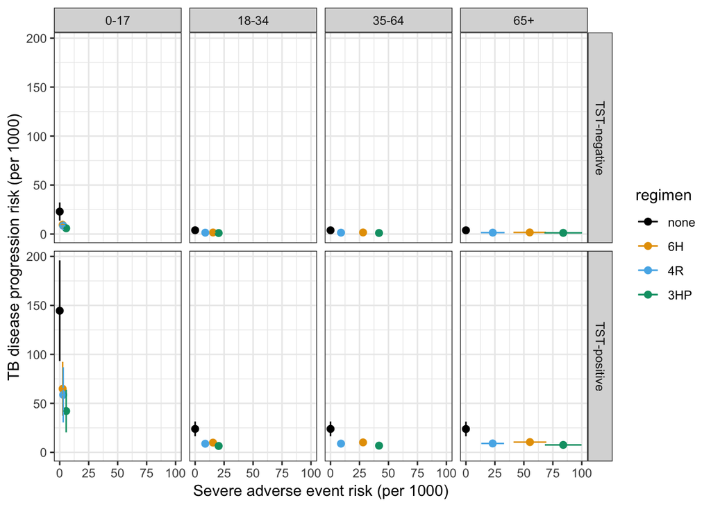

```r
Figure2
```

```r
## Figure2 <- Figure2 + theme_bw() #+ ggpubr::grids(linetype = "dashed")
ggsave(Figure2,file='figures/Figure2.pdf',height = 5,width=10)
```

In terms of risk differences wrt no PT, this looks like:

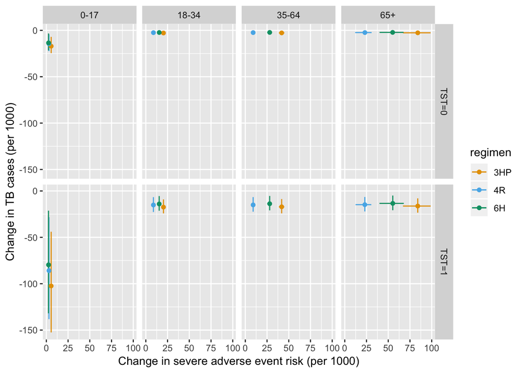

```r
GP2
```

Table of NNH/NNT

```r
knitr::kable(DFWM2[,.(LTBI,acat,regimen,
                      NNT=ceiling(NNT),
                      NNH=floor(NNH))])
```

| LTBI | acat | regimen | NNT | NNH |
| --- | --- | --- | --- | --- |
| 0 | 0-17 | 3HP | 59 | 179 |
| 0 | 0-17 | 4R | 70 | 335 |
| 0 | 0-17 | 6H | 74 | 395 |
| 0 | 18-34 | 3HP | 351 | 49 |
| 0 | 18-34 | 4R | 405 | 114 |
| 0 | 18-34 | 6H | 435 | 64 |
| 0 | 35-64 | 3HP | 367 | 23 |
| 0 | 35-64 | 4R | 416 | 110 |
| 0 | 35-64 | 6H | 453 | 35 |
| 0 | 65+ | 3HP | 379 | 11 |
| 0 | 65+ | 4R | 421 | 43 |
| 0 | 65+ | 6H | 457 | 18 |
| 1 | 0-17 | 3HP | 10 | 180 |
| 1 | 0-17 | 4R | 12 | 333 |
| 1 | 0-17 | 6H | 13 | 398 |
| 1 | 18-34 | 3HP | 58 | 49 |
| 1 | 18-34 | 4R | 67 | 114 |
| 1 | 18-34 | 6H | 72 | 64 |
| 1 | 35-64 | 3HP | 59 | 23 |
| 1 | 35-64 | 4R | 67 | 110 |
| 1 | 35-64 | 6H | 73 | 35 |
| 1 | 65+ | 3HP | 62 | 11 |
| 1 | 65+ | 4R | 68 | 43 |
| 1 | 65+ | 6H | 75 | 18 |

Ways to examine the usefulness of the TST in various cases. First as risk differences

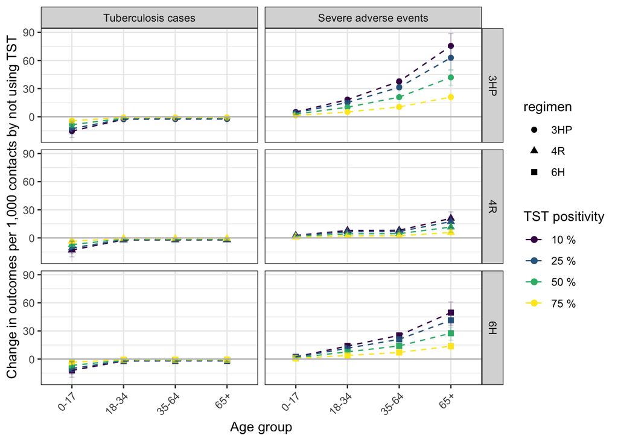

```r
Figure3
```

```r
## Figure3 <- Figure3 + theme_classic() + ggpubr::grids(linetype = "dashed")
ggsave(Figure3,file=here('figures/Figure3.pdf'),w=7,h=7)
ggsave(Figure3v2,file=here('figures/Figure3v2.pdf'),w=7,h=7)
```

Figure for text

0-17 & 25% LTBI

```r
DLM4a[acat=='0-17' & LTBI=='25 %'][,.(regimen,qty,
                                      mid=round(1e3*mid),
                                      lo=round(1e3*lo),
                                      hi=round(1e3*hi))]
```

```
##    regimen qty mid lo  hi
## 1:     3HP  AE   4  6   2
## 2:      4R  AE   2  3   1
## 3:      6H  AE   2  3   1
## 4:     3HP  TB -13 -5 -18
## 5:      4R  TB -11 -3 -17
## 6:      6H  TB -10 -3 -16
```

> 65 & 25% LTBI

```r
DLM4a[acat=='65+' & LTBI=='25 %'][,.(regimen,qty,
                                    mid=round(1e3*mid),
                                    lo=round(1e3*lo),
                                    hi=round(1e3*hi))]
```

```
##    regimen qty mid lo hi
## 1:     3HP  AE  63 74 50
## 2:      4R  AE  17 23  9
## 3:      6H  AE  41 51 30
## 4:     3HP  TB  -2 -1 -3
## 5:      4R  TB  -2 -1 -3
## 6:      6H  TB  -2  0 -3
```

One against other

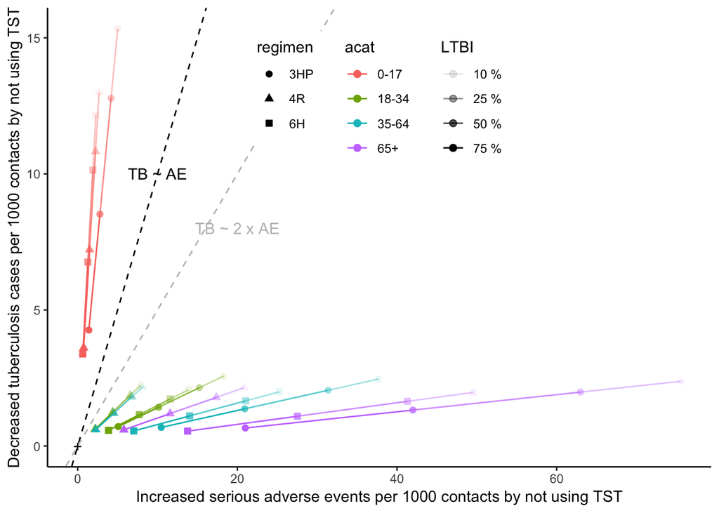

```r
GP4b
```

```r
ggsave(GP4b,file=here('figures/S_GP4b.pdf'))
```

# Analyses for hypothetical populations

Suggested table 3 (slightly modified)

```r
knitr::kable(Table3pretty)
```

| regimen | acat | all_tb | all_ae | tst_tb | tst_ae |
| --- | --- | --- | --- | --- | --- |
| none | 0-17 | 53.3 (37.3,66.5) | 0.0 ( 0.0, 0.0) | 53.3 (37.3,66.5) | 0.0 ( 0.0, 0.0) |
| none | 18-34 | 8.9 ( 6.5,10.8) | 0.0 ( 0.0, 0.0) | 8.9 ( 6.5,10.8) | 0.0 ( 0.0, 0.0) |
| none | 35-64 | 8.8 ( 6.6,10.7) | 0.0 ( 0.0, 0.0) | 8.8 ( 6.6,10.7) | 0.0 ( 0.0, 0.0) |
| none | 65+ | 8.8 ( 6.5,10.7) | 0.0 ( 0.0, 0.0) | 8.8 ( 6.5,10.7) | 0.0 ( 0.0, 0.0) |
| 6H | 0-17 | 23.3 (15.2,29.2) | 2.5 ( 0.7, 3.5) | 33.4 (22.8,41.6) | 0.6 ( 0.2, 0.9) |
| 6H | 18-34 | 3.7 ( 2.6, 4.5) | 15.4 (13.1,17.5) | 5.4 ( 3.9, 6.5) | 3.9 ( 3.3, 4.4) |
| 6H | 35-64 | 3.7 ( 2.7, 4.6) | 28.1 (25.2,30.8) | 5.4 ( 4.0, 6.5) | 7.0 ( 6.3, 7.7) |
| 6H | 65+ | 3.9 ( 2.7, 4.7) | 55.1 (40.0,67.6) | 5.5 ( 4.0, 6.7) | 13.8 (10.0,16.9) |
| 4R | 0-17 | 21.0 (12.9,26.7) | 3.0 ( 0.9, 4.2) | 31.9 (21.3,39.7) | 0.7 ( 0.2, 1.0) |
| 4R | 18-34 | 3.3 ( 2.2, 4.0) | 8.8 ( 7.0,10.3) | 5.1 ( 3.6, 6.2) | 2.2 ( 1.7, 2.6) |
| 4R | 35-64 | 3.3 ( 2.2, 4.1) | 9.0 ( 7.3,10.5) | 5.1 ( 3.6, 6.3) | 2.3 ( 1.8, 2.6) |
| 4R | 65+ | 3.4 ( 2.2, 4.1) | 23.1 (12.0,30.9) | 5.1 ( 3.6, 6.3) | 5.8 ( 3.0, 7.7) |
| 3HP | 0-17 | 14.9 ( 8.8,18.8) | 5.6 ( 2.9, 7.4) | 27.7 (18.2,34.9) | 1.4 ( 0.7, 1.9) |
| 3HP | 18-34 | 2.4 ( 1.5, 3.0) | 20.3 (17.6,22.6) | 4.5 ( 3.2, 5.5) | 5.1 ( 4.4, 5.7) |
| 3HP | 35-64 | 2.5 ( 1.6, 3.1) | 41.8 (38.6,44.9) | 4.6 ( 3.2, 5.6) | 10.5 ( 9.7,11.2) |
| 3HP | 65+ | 2.8 ( 1.9, 3.4) | 84.0 (67.0,98.7) | 4.8 ( 3.4, 5.8) | 21.0 (16.7,24.7) |

Suggested table 4

Output table

```r
knitr::kable(Table4pretty)
```

| regimen | lb_tb | lb_ae | hb_tb | hb_ae |
| --- | --- | --- | --- | --- |
| 6H | -2.5 (-3.4 , -1.6) | 25.7 (22.0 , 28.8) | -3.3 (-5.0 , -1.3) | 6.2 (5.6 , 6.8) |
| 4R | -2.7 (-3.6 , -1.8) | 10.9 ( 8.2 , 12.8) | -3.6 (-5.2 , -1.5) | 3.3 (2.7 , 3.8) |
| 3HP | -3.1 (-3.9 , -2.2) | 37.9 (33.8 , 41.4) | -4.2 (-5.7 , -2.2) | 9.1 (8.3 , 9.8) |